# 00_特別講座資料（演習問題集）_2022_解答付

**2022年度 東京成徳大学 特別講座 資料**  
**東京工科大学コンピュータサイエンス学部**  
**福西広晃**

**演習問題を解く際は、必要に応じてセルを増やして頂いて構いません**

**必要に応じで以下を実行してください**

**japanize-matplotlibインストール**

```python
pip install japanize-matplotlib
```

**Googleドライブにアクセス**

```python
from google.colab import drive
drive.mount('/content/drive')
```

# 演習問題1

変数num1が`1`または`4`の場合はnum1に2を足し、`2`または`7`の場合はnum1に3を引き、`5`または`9`の場合はnum1に4を掛け、`3`の場合はnum1を`2`で割り、それ以外の場合は何もしないプログラムを作成してみよう。num1の初期値は7とする。

解答例

```python
num1 = 7

if num1 == 1 or num1 == 4:
    num1 = num1 + 2
elif num1 == 2 or num1 == 7:
    num1 = num1 - 3
elif num1 == 5 or num1 == 9:
    num1 = num1 * 4
elif num1 == 3:
    num1 = num1 / 2

print("出力: ", num1)
```

```
出力:  4
```

# 演習問題2

- num2という変数に代入された数値によって以下の表示になるプログラムを作成してみよう。num2の初期値は7とする。
  - 2の倍数だが、3の倍数でないの場合は、「2の倍数」と表示
  - 3の倍数だが、2の倍数でないの場合は、「3の倍数」と表示
  - 3の倍数、かつ、2の倍数であるの場合は、「2の倍数かつ3の倍数」と表示
  - それ以外は、「2の倍数でも3の倍数でもない」と表示  
    ヒント：Xの倍数の判定する場合、数値をXで割って余りが0ならXの倍数となる
- num2の値をいろいろ変化させて、試してみよう

解答例

```python
num2 = 7

# 最初のif文で2の倍数かつ3の倍数を判定させると、
# elifでは2の倍数か3の倍数かだけを判定すればよい
if(num2 % 2 == 0 and num2 % 3 == 0):
    print("2の倍数かつ3の倍数")
elif(num2 % 2 == 0):
    print("2の倍数")
elif(num2 % 3 == 0):
    print("3の倍数")
else:
    print("2の倍数でも3の倍数でもない")
```

```
2の倍数でも3の倍数でもない
```

# 演習問題3

- チケットの価格は以下のように設定されている。
  - 18歳未満の男は1000円
  - 18歳未満の女は800円
  - それ以外は2000円
- 年齢と性別によって価格を表示するプログラムを作成してみよう。年齢を表す変数を`nenrei`、性別を表す変数を`seibetu`とする。20歳男性の料金を表示してみよう。

解答例

```python
nenrei  =  20   #　年齢
seibetu =  "男" #  性別

if nenrei < 18 and seibetu == "男":
    price = 1000
elif nenrei < 18 and seibetu == "女":
    price = 800
else:
    price = 2000

print("価格: ",price,"円")
```

```
価格:  2000 円
```

# 演習問題4

1000から5000までの整数の中で、5の倍数と7の倍数の整数の合計を計算してみよう。合計を表す変数は`total`とする。最後に合計を表示してみよう。

解答例

```python
total = 0

for i in range(1000, 5001):
    amari5 = i % 5
    amari7 = i % 7
    if(amari5 == 0 or amari7 == 0):
        total = total + i
print(total)
```

```
3777569
```

# 演習問題5

解答例

```python
initial = 10000     # 初期投資額
total   = initial   # 初期の合計金額

for i in range(1, 31):
    if(i <= 5):
        total = total * 1.035
    elif(i >= 6 and i <= 15):
        total = total * 1.017
    elif(i >= 16 and i <= 27):
        total = total * 1.024
    else:
        total = total * 1.027

print(total/initial)
```

```
2.0240539708267637
```

# 演習課題6

以下のテストの点数を含むリスト`scores1`がある。降順で並び替えて、上から5人目の点数を表示してみよう。

```python
score1 = [80, 64, 85, 79, 52, 91, 82, 74, 85, 66, 73, 68, 80, 58, 78, 91]
```

解答例

```python
score1 = sorted(score1, reverse=True)
print(score1)
print(score1[4])
```

```
[91, 91, 85, 85, 82, 80, 80, 79, 78, 74, 73, 68, 66, 64, 58, 52]
82
```

# 演習問題7

```python
score2 = [80, 64, 85, 79, 52, 91, 82, 74, 85, 66, 73, 68, 80, 58, 78, 91]
```

解答例

```python
judgements = [] # 空リストを準備

for i in score2:
    if(i > 90):
        judgements.append("S")
    elif(i > 80):
        judgements.append("A")
    elif(i > 70):
        judgements.append("B")
    elif(i > 60):
        judgements.append("C")
    else:
        judgements.append("D")

print(judgements)
```

```
['B', 'C', 'A', 'B', 'D', 'S', 'A', 'B', 'A', 'C', 'B', 'C', 'B', 'D', 'B', 'S']
```

# 演習問題8

以下のセルでは、都道府県の人口データをpandasのデータフレームに読み込んでいる。次の手順で分析してみよう。

- 男性人口率の列を追加する（男性人口率 = 人口（男）/ 人口（総数））
- 昭和5年の各都道府県のデータを抽出する
- 男性人口率を降順で並び替え
- 男性人口率上位5都道府県を表示する
- 男性人口率下位5頭道府県を表示する

```python
import pandas as pd

# ファイルの指定
# Google Colaboratoryの場合
file = "drive/My Drive/Colab Notebooks/dataset/都道府県別人口推移.xlsx"

# Anacondaの場合(Google Colaboratoryの場合は削除してください)
file = "dataset/都道府県別人口推移.xlsx"

# データの読み込み
df_population = pd.read_excel(file, sheet_name="Sheet1")
```

解答例

```python
df_population["男性人口率"] = df_population["人口（男）"]/df_population["人口（総数）"]

TrueFalse       = (df_population["元号"] == "昭和") & (df_population["和暦（年）"]==5)

df_population_2 = df_population[TrueFalse]

df_sort         = df_population_2.sort_values(by="男性人口率", ascending=False)

display(df_sort.head(5))

display(df_sort.tail(5))
```

|  | 都道府県コード | 都道府県名 | 元号 | 和暦（年） | 西暦（年） | 人口（総数） | 人口（男） | 人口（女） | 男性人口率 |
| --- | --- | --- | --- | --- | --- | --- | --- | --- | --- |
| 106 | 13 | 東京都 | 昭和 | 5 | 1930 | 5408678 | 2855323 | 2553355 | 0.527915 |
| 94 | 1 | 北海道 | 昭和 | 5 | 1930 | 2812335 | 1468540 | 1343795 | 0.522178 |
| 120 | 27 | 大阪府 | 昭和 | 5 | 1930 | 3540017 | 1845786 | 1694231 | 0.521406 |
| 107 | 14 | 神奈川県 | 昭和 | 5 | 1930 | 1619606 | 839309 | 780297 | 0.518218 |
| 135 | 42 | 長崎県 | 昭和 | 5 | 1930 | 1233362 | 630525 | 602837 | 0.511225 |

|  | 都道府県コード | 都道府県名 | 元号 | 和暦（年） | 西暦（年） | 人口（総数） | 人口（男） | 人口（女） | 男性人口率 |
| --- | --- | --- | --- | --- | --- | --- | --- | --- | --- |
| 118 | 25 | 滋賀県 | 昭和 | 5 | 1930 | 691631 | 337016 | 354615 | 0.487277 |
| 110 | 17 | 石川県 | 昭和 | 5 | 1930 | 756835 | 368402 | 388433 | 0.486767 |
| 113 | 20 | 長野県 | 昭和 | 5 | 1930 | 1717118 | 832312 | 884806 | 0.484715 |
| 139 | 46 | 鹿児島県 | 昭和 | 5 | 1930 | 1556690 | 753644 | 803046 | 0.484132 |
| 140 | 47 | 沖縄県 | 昭和 | 5 | 1930 | 577509 | 272797 | 304712 | 0.472368 |

# 演習問題9

以下のセルでは、アパレルの販売データをpandasのデータフレームに読み込んでいる。ピボットテーブルを用いて、各社員の月ごとの売上金額の合計をクロス集計し、表示してみよう。結果を見て、月ごとにトップ成績の社員を挙げてみよう。

```python
import pandas as pd

# ファイルの指定
# Google Colaboratoryの場合
file = "drive/My Drive/Colab Notebooks/dataset/販売データ.xlsx"

# Anacondaの場合(Google Colaboratoryの場合は削除してください)
file = "dataset/販売データ.xlsx"

# データをpandasで読み込み
df_sale = pd.read_excel(file, sheet_name="実績管理表")
```

解答例

```python
df_pivot = df_sale.pivot_table(index   = "社員ID",    # 集計単位の列名1
                               columns = "売上月",    # 集計単位の列名2
                               values  = "売上金額",  # 集計する列名
                               aggfunc = "sum",       # 集計方法
                               margins = True,        # 合計の追加
                               margins_name = "合計", # 合計に使用する項目名
                               fill_value= 0)         # 欠損値には0を代入
# 集計結果を出力
display(df_pivot)
```

| 売上月 社員ID | 1 | 2 | 3 | 4 | 5 | 6 | 7 | 8 | 9 | 10 | 11 | 12 | 合計 |
| --- | --- | --- | --- | --- | --- | --- | --- | --- | --- | --- | --- | --- | --- |
| a003 | 218000 | 110000 | 12000 | 178000 | 160000 | 238000 | 198000 | 308000 | 132000 | 162000 | 391000 | 362000 | 2469000 |
| a013 | 158000 | 70000 | 215000 | 70000 | 30000 | 108000 | 85000 | 281000 | 275000 | 127000 | 205000 | 63000 | 1687000 |
| a023 | 56000 | 70000 | 103000 | 110000 | 200000 | 248000 | 84000 | 288000 | 204000 | 73000 | 166000 | 198000 | 1800000 |
| a036 | 103000 | 24000 | 80000 | 54000 | 107000 | 130000 | 126000 | 342000 | 62000 | 105000 | 158000 | 148000 | 1439000 |
| a047 | 137000 | 243000 | 90000 | 64000 | 58000 | 102000 | 246000 | 0 | 56000 | 113000 | 230000 | 9000 | 1348000 |
| a051 | 0 | 0 | 65000 | 35000 | 0 | 48000 | 144000 | 124000 | 28000 | 9000 | 94000 | 0 | 547000 |
| a052 | 70000 | 0 | 60000 | 0 | 0 | 84000 | 0 | 52000 | 43000 | 0 | 8000 | 72000 | 389000 |
| 合計 | 742000 | 517000 | 625000 | 511000 | 555000 | 958000 | 883000 | 1395000 | 800000 | 589000 | 1252000 | 852000 | 9679000 |

# 演習課題10

以下のセルでは、都道府県の人口データをpandasのデータフレームに読み込んでいる。2015年の人口（総数）上位5都道府県の人口（総数）の推移を折れ線グラフで可視化してみよう。グラフは`matplotlib`を使用するものとする。次の手順を参考にしよう。

- 2015年データを抽出した後、都道府県別人口（総数）で並び替えを行い、上位5都道府県を選ぶ
- 都道府県ごとに1920-2015年までのデータを抽出する
- データフレームの`西暦（年）`列と、`人口（総数）`列を用いて、折れ線グラフを作成
- グラフには`タイトル`、`xラベル`、`yラベル`、`凡例`、`補助線`を加える
- グラフの画像を`上位5都市人口推移.png`を出力し、確認する

```python
import pandas as pd

# ファイルの指定
# Google Colaboratoryの場合
file = "drive/My Drive/Colab Notebooks/dataset/都道府県別人口推移.xlsx"

# Anacondaの場合(Google Colaboratoryの場合は削除してください)
file = "dataset/都道府県別人口推移.xlsx"

# データの読み込み
df_population = pd.read_excel(file, sheet_name="Sheet1")
```

解答例

```python
TrueFalse = df_population["西暦（年）"]==2015
display(df_population[TrueFalse].sort_values(by="人口（総数）", ascending=False))
```

|  | 都道府県コード | 都道府県名 | 元号 | 和暦（年） | 西暦（年） | 人口（総数） | 人口（男） | 人口（女） |
| --- | --- | --- | --- | --- | --- | --- | --- | --- |
| 904 | 13 | 東京都 | 平成 | 27 | 2015 | 13515271 | 6666690 | 6848581 |
| 905 | 14 | 神奈川県 | 平成 | 27 | 2015 | 9126214 | 4558978 | 4567236 |
| 918 | 27 | 大阪府 | 平成 | 27 | 2015 | 8839469 | 4256049 | 4583420 |
| 914 | 23 | 愛知県 | 平成 | 27 | 2015 | 7483128 | 3740844 | 3742284 |
| 902 | 11 | 埼玉県 | 平成 | 27 | 2015 | 7266534 | 3628418 | 3638116 |
| 903 | 12 | 千葉県 | 平成 | 27 | 2015 | 6222666 | 3095860 | 3126806 |
| 919 | 28 | 兵庫県 | 平成 | 27 | 2015 | 5534800 | 2641561 | 2893239 |
| 892 | 1 | 北海道 | 平成 | 27 | 2015 | 5381733 | 2537089 | 2844644 |
| 931 | 40 | 福岡県 | 平成 | 27 | 2015 | 5101556 | 2410418 | 2691138 |
| 913 | 22 | 静岡県 | 平成 | 27 | 2015 | 3700305 | 1820993 | 1879312 |
| 899 | 8 | 茨城県 | 平成 | 27 | 2015 | 2916976 | 1453594 | 1463382 |
| 925 | 34 | 広島県 | 平成 | 27 | 2015 | 2843990 | 1376211 | 1467779 |
| 917 | 26 | 京都府 | 平成 | 27 | 2015 | 2610353 | 1248972 | 1361381 |
| 895 | 4 | 宮城県 | 平成 | 27 | 2015 | 2333899 | 1140167 | 1193732 |
| 906 | 15 | 新潟県 | 平成 | 27 | 2015 | 2304264 | 1115413 | 1188851 |
| 911 | 20 | 長野県 | 平成 | 27 | 2015 | 2098804 | 1022129 | 1076675 |
| 912 | 21 | 岐阜県 | 平成 | 27 | 2015 | 2031903 | 983850 | 1048053 |
| 900 | 9 | 栃木県 | 平成 | 27 | 2015 | 1974255 | 981626 | 992629 |
| 901 | 10 | 群馬県 | 平成 | 27 | 2015 | 1973115 | 973283 | 999832 |
| 924 | 33 | 岡山県 | 平成 | 27 | 2015 | 1921525 | 922226 | 999299 |
| 898 | 7 | 福島県 | 平成 | 27 | 2015 | 1914039 | 945660 | 968379 |
| 915 | 24 | 三重県 | 平成 | 27 | 2015 | 1815865 | 883516 | 932349 |
| 934 | 43 | 熊本県 | 平成 | 27 | 2015 | 1786170 | 841046 | 945124 |
| 937 | 46 | 鹿児島県 | 平成 | 27 | 2015 | 1648177 | 773061 | 875116 |
| 938 | 47 | 沖縄県 | 平成 | 27 | 2015 | 1433566 | 704619 | 728947 |
| 916 | 25 | 滋賀県 | 平成 | 27 | 2015 | 1412916 | 696941 | 715975 |
| 926 | 35 | 山口県 | 平成 | 27 | 2015 | 1404729 | 665008 | 739721 |
| 929 | 38 | 愛媛県 | 平成 | 27 | 2015 | 1385262 | 654380 | 730882 |
| 933 | 42 | 長崎県 | 平成 | 27 | 2015 | 1377187 | 645763 | 731424 |
| 920 | 29 | 奈良県 | 平成 | 27 | 2015 | 1364316 | 643946 | 720370 |
| 893 | 2 | 青森県 | 平成 | 27 | 2015 | 1308265 | 614694 | 693571 |
| 894 | 3 | 岩手県 | 平成 | 27 | 2015 | 1279594 | 615584 | 664010 |
| 935 | 44 | 大分県 | 平成 | 27 | 2015 | 1166338 | 551932 | 614406 |
| 908 | 17 | 石川県 | 平成 | 27 | 2015 | 1154008 | 558589 | 595419 |
| 897 | 6 | 山形県 | 平成 | 27 | 2015 | 1123891 | 540226 | 583665 |
| 936 | 45 | 宮崎県 | 平成 | 27 | 2015 | 1104069 | 519242 | 584827 |
| 907 | 16 | 富山県 | 平成 | 27 | 2015 | 1066328 | 515147 | 551181 |
| 896 | 5 | 秋田県 | 平成 | 27 | 2015 | 1023119 | 480336 | 542783 |
| 928 | 37 | 香川県 | 平成 | 27 | 2015 | 976263 | 472308 | 503955 |
| 921 | 30 | 和歌山県 | 平成 | 27 | 2015 | 963579 | 453216 | 510363 |
| 910 | 19 | 山梨県 | 平成 | 27 | 2015 | 834930 | 408327 | 426603 |
| 932 | 41 | 佐賀県 | 平成 | 27 | 2015 | 832832 | 393073 | 439759 |
| 909 | 18 | 福井県 | 平成 | 27 | 2015 | 786740 | 381474 | 405266 |
| 927 | 36 | 徳島県 | 平成 | 27 | 2015 | 755733 | 359790 | 395943 |
| 930 | 39 | 高知県 | 平成 | 27 | 2015 | 728276 | 342672 | 385604 |
| 923 | 32 | 島根県 | 平成 | 27 | 2015 | 694352 | 333112 | 361240 |
| 922 | 31 | 鳥取県 | 平成 | 27 | 2015 | 573441 | 273705 | 299736 |

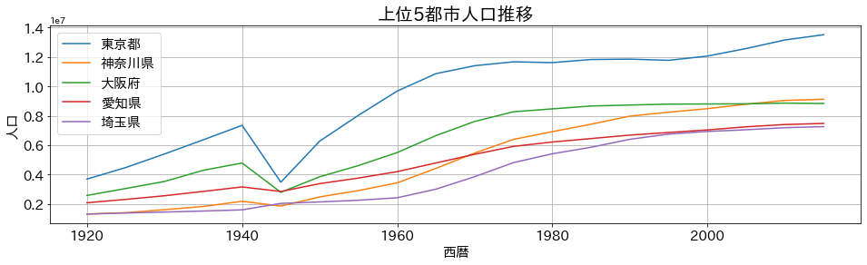

```python
# データ抽出
df_tokyo    = df_population[df_population["都道府県名"]=="東京都"]
df_kanagawa = df_population[df_population["都道府県名"]=="神奈川県"]
df_osaka    = df_population[df_population["都道府県名"]=="大阪府"]
df_aichi    = df_population[df_population["都道府県名"]=="愛知県"]
df_saitama  = df_population[df_population["都道府県名"]=="埼玉県"]

# 作図に必要なライブラリのインポート
import matplotlib.pyplot as plt # グラフ作成のためにインポート
import japanize_matplotlib      # グラフで日本語を使用するためにインポート
%matplotlib inline

# グラフ作成
plt.figure(figsize=(16,4))
plt.plot(df_tokyo["西暦（年）"],    df_tokyo["人口（総数）"],    label="東京都")
plt.plot(df_kanagawa["西暦（年）"], df_kanagawa["人口（総数）"], label="神奈川県")
plt.plot(df_osaka["西暦（年）"],    df_osaka["人口（総数）"],    label="大阪府")
plt.plot(df_aichi["西暦（年）"],    df_aichi["人口（総数）"],    label="愛知県")
plt.plot(df_saitama["西暦（年）"],  df_saitama["人口（総数）"],  label="埼玉県")

# 追加オプション
plt.title("上位5都市人口推移", fontsize=20) # タイトルを追加（フォントサイズ指定）
plt.xlabel("西暦", fontsize=15) # x軸のラベルを追加（フォントサイズ指定）
plt.ylabel("人口", fontsize=15)  # y軸のラベルを追加（フォントサイズ指定）
plt.xticks(fontsize=15)  # x軸の目盛のフォントサイズ変更
plt.yticks(fontsize=15)  # x軸の目盛のフォントサイズ変更
plt.legend(loc="best", fontsize=15)
plt.grid()

# 出力ファイル名を指定（Googleドライブの場合）
outfile = "drive/My Drive/Colab Notebooks/グラフ_上位5都市人口推移.png"

# # 出力ファイル名を指定（Anacondaの場合, Google Colaboratoryの場合は削除してください)
outfile = "グラフ_上位5都市人口推移.png"

plt.savefig(outfile, bbox_inches='tight') # 画像の保存

# グラフ表示
plt.show()
```